# Study & Phone

A snapshot of phone usage during my study sessions

Xin Li

2025-05-11

## Studying… or So I Thought?

As a full-time Stage 3 Computer Science student, I *feel* like I’m always studying - or I shall say, I’m always *sitting down* with my *study ambitions*.

Whenever I study at home or on campus, my ritual goes something like this:

1. Prepare a cup of coffee, hot or iced, with milk, but never sugar.
2. Pick a random chocolate from the box. Any flavour works, as long as it’s sweet.
3. Find a sunny spot by the window, preferably with a view of something green.
4. Review my to-do list and choose a task to kick off.
5. And finally…. study time (in theory)!

*“Today, I shall conquer all the tasks… unless my phone conquers me first.” – Xin Li*

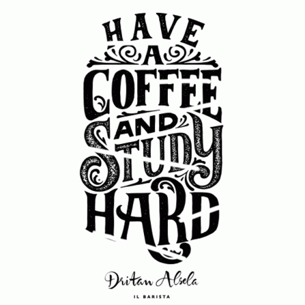

Have a coffee and study hard

## Yes, I *Did* Study!

Believe it or not, I have logged 54 study sessions in total! Ka pai!

Each session ranged from 50 to 300 minutes (yes, some were longer than I expected - go me!).

As you can see from the graph below, it turns out that I studied the most times on Friday, ranking up 13 sessions in that day of the week.

On the flip side, Thursday didn’t seem to have much of my study actions… apparently, my brain (unintentionally) took that day off during the week. 😅

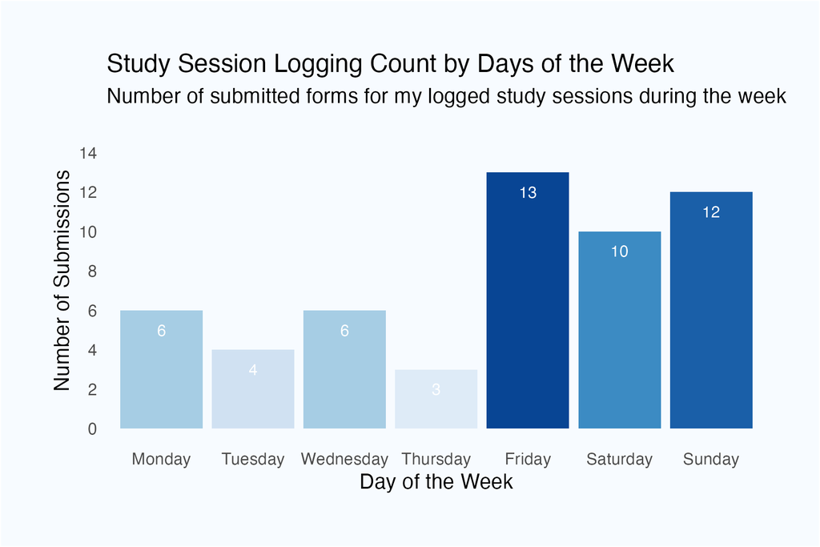

My Study Session Counts over the Week

## Spoiler: My Phone Is My Best Friend

Now you might be wondering: *Did I ever get distracted by my phone during my study sessions?* (No doubt here - the answer is obviously yes.)

But how often did it happen? Was I more distracted at certain times of the day? Or am I just… can be easily distracted by my phone whenever?

My logged data is telling me that I generally picked up my phone the most in the Evening(5PM-9PM). Across the 16 sessions during the Evening(5PM-9PM), I reached for my phone a whopping 103 times in total - that’s an average of 6.4 phone pickups per session! 😭

On the brighter side, my most focused time during the day was Morning(6AM-12PM). Across all the 15 study sessions during that period, I picked up my phones 27 times in sum - that’s just 1.8 phone pickups per session. Pretty impressive, right?

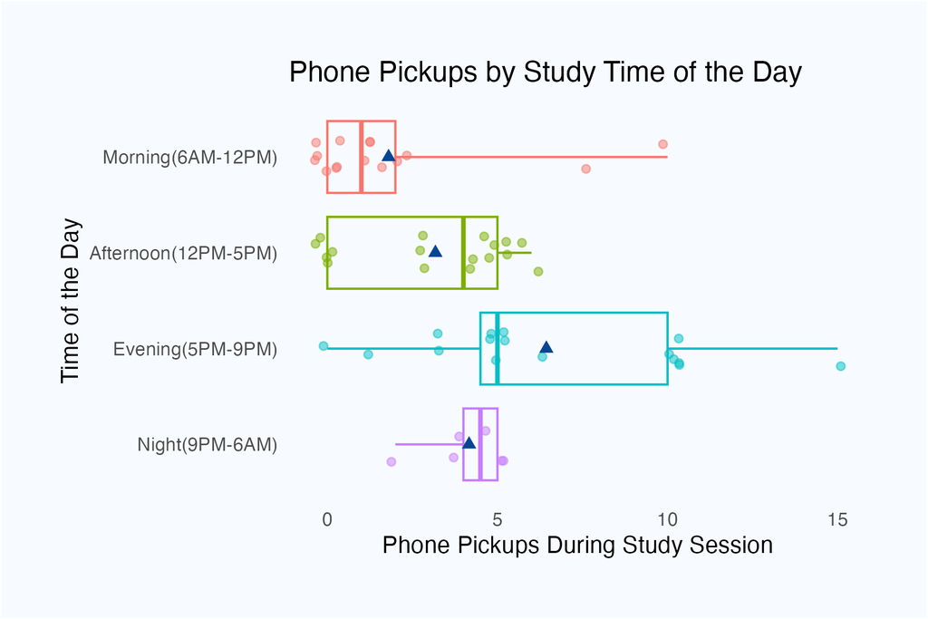

Phone Usage Frequency by Study Time of the Day

## What *Stole* My Focus?

Oh well, what was I actually doing on my phone?

Different times of the day, different vibes… and maybe, different distractions, too?

In the **morning**, I mostly got sidetracked by Chat, taking up 50% of all my phone usage in that time slot.

In the **evening**, I mainly spent my time on phone for Game, stealing away 60% of all my focus. Maybe it’s the time for me to unwind…?

And as for the **night**, when the world goes quiet, it’s my turn to do some Game, which took up 50% of my nighttime phone use.

Hmm… I didn’t realise my distractions had a schedule too!

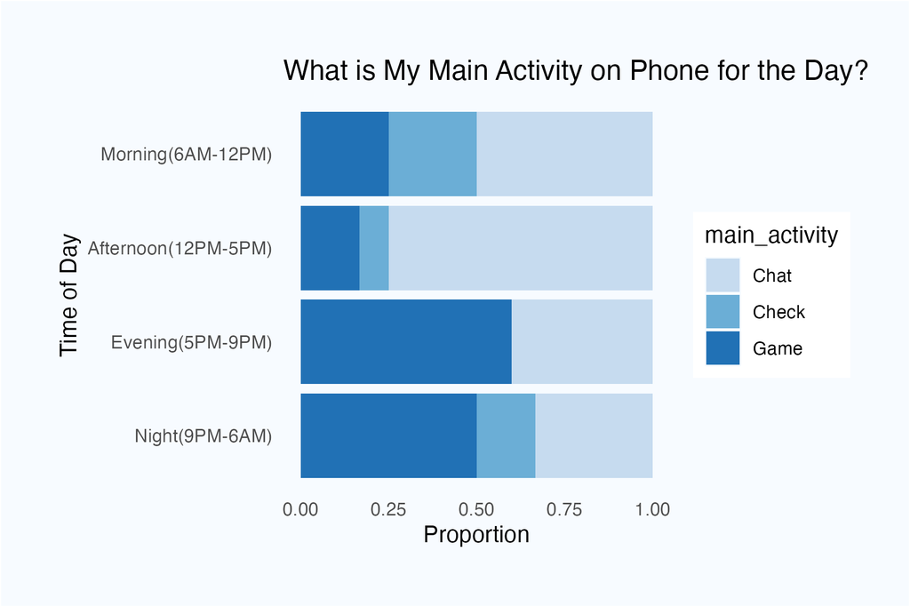

What is My Main Activity on Phone During the Day

## After All…

Here’s a fun fact to wrap things up:

It’s currently 1AM (yes, midnight again) and I’ve been working on this visual story for nearly **four hours** straight…

And guess what? I’ve only picked up my phone **once** - just to check the time!

So… *what does this tell us?*

Maybe… *deadlines* are just **stronger** than *phone distractions*? 😭

[figure not shown]

Fun Statistics